# Ford GoBike Data Exploration

Some brief insights regarding the bike service GoBike

## How long does the users use the service

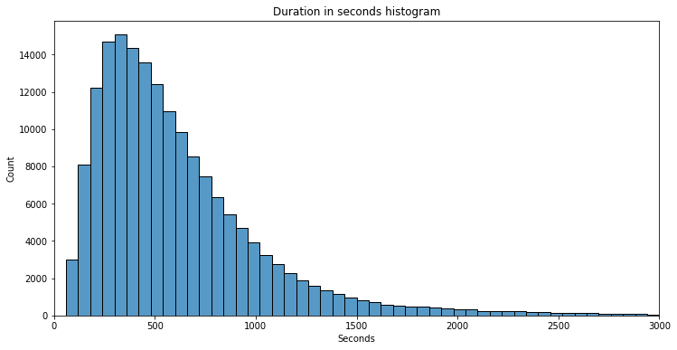

#### Customers tend to travel in relatively short durations.

## What is the distribution of the **'member_birth_year'** feature?

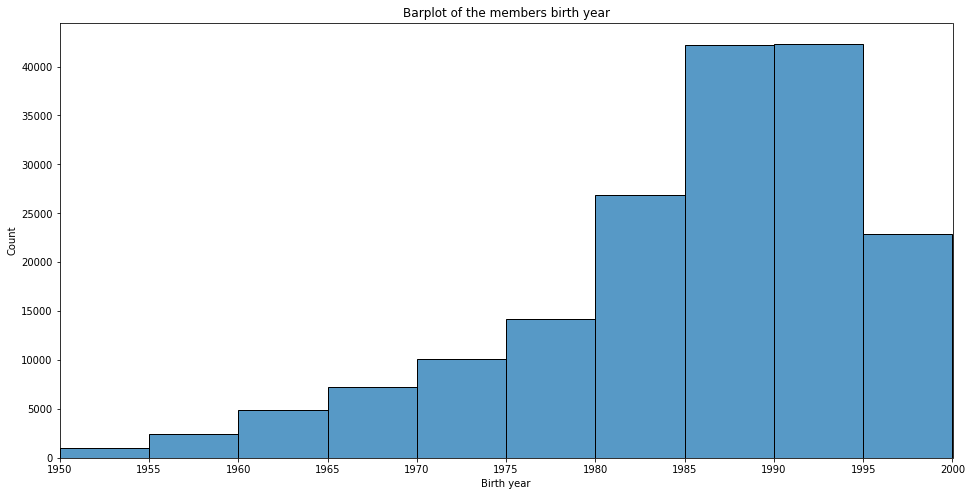

## The distrubution for renting bikes duration in minutes for genders,for different types of users.

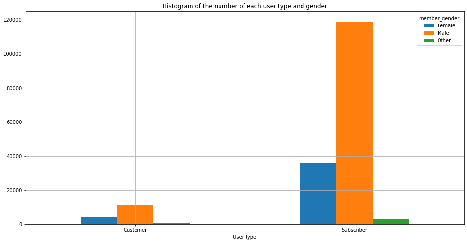

#### This service has more subscribers than customers, and it appeals more to male members, with a huge margin compared to female members.

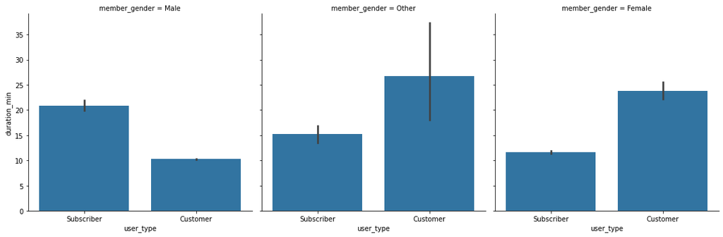

Males tend rent bikes longer when they are subscribers, females and others go against this trend, from the prior plot we can ignore the **'other'** and build our conclusions from the remaining values, since they are a rarity in this dataset.

## what is the distrubution of the service members according to thier birth year and gender?

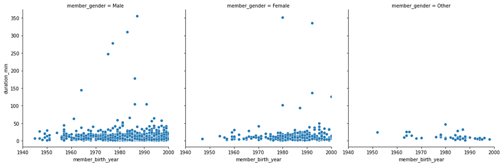

## How often do member use this service across different days of the week?

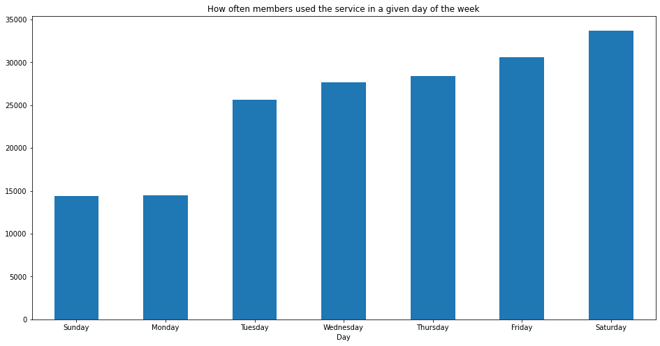

## Which hours are the busiest during the day?

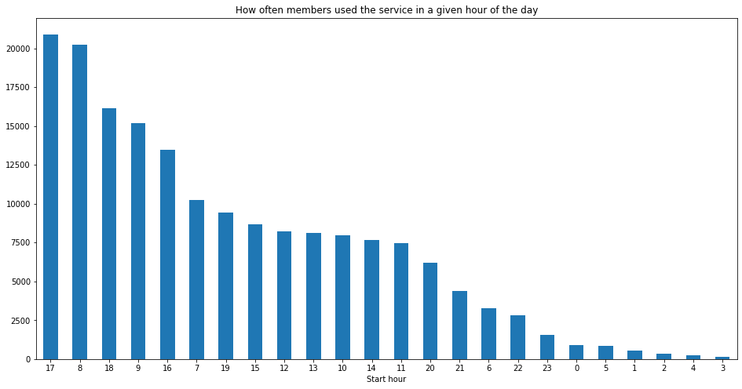

## What is the total distance distribution for different days of the week.

```
Total distance of the trips for customers and members in each day of the week
```

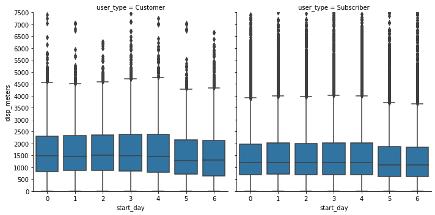

Majority of our users have trips with a total distance of 500m and 2000m.

## Thank You :)